# HEART DISEASE DETECTION

Daniel García Zapata  
Carles  
Barath

```python
from IPython.display import HTML
HTML('''<script>
code_show=true;
function code_toggle() {
 if (code_show){
 $('div.input').hide();
 } else {
 $('div.input').show();
 }
 code_show = !code_show
}
$( document ).ready(code_toggle);
</script>
The raw code for this IPython notebook is by default hidden for easier reading.
To toggle on/off the raw code, click <a href="javascript:code_toggle()">here</a>.''')
```

The raw code for this IPython notebook is by default hidden for easier reading. To toggle on/off the raw code, click here.

# HEART DISEASE

Heart disease describes a range of conditions that affect your heart. Diseases under the heart disease umbrella include blood vessel diseases, such as coronary artery disease; heart rhythm problems (arrhythmias); and heart defects you're born with (congenital heart defects), among others.

Coronary heart disease is a common term for the buildup of plaque in the heart’s arteries that could lead to heart attack. However, coronary heart disease, or CHD, is a result of coronary artery disease, or CAD, said Edward A. Fisher, M.D., Ph.D., M.P.H. [1]

[figure not shown]

## DATA EXPLORATION

The data that we have used to build the decision support system consists of two different datasets that have the same number and types of attributes. One is the Cleveland Heart Disease Dataset, which contains 303 instances with 14 attributes, and the other one is the Statlog Heart Dataset, which contains 266 instances with the exact same attributes.

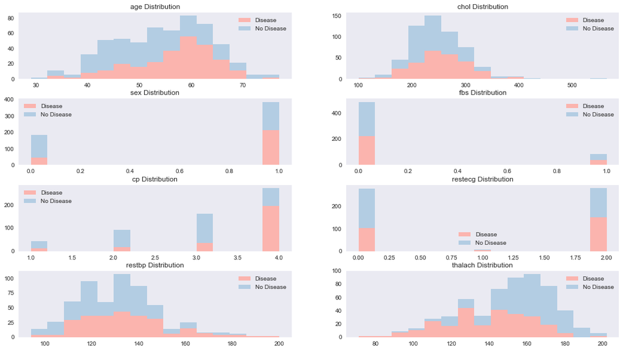

```python
'''
FEATURE VISUALIZATION
'''
current_palette = sns.color_palette('Pastel1')
sns.set_palette(current_palette)

# Plot the distribution of each variable
fig, ax = plt.subplots(4, 2, figsize=(18, 10))
for en, var in enumerate(ex1.columns.values):
    i = (lambda:0, lambda:1)[en > 3]()
    e = (lambda:e+1, lambda:0)[en == 4 or en == 0]()
    ax[e,i].hist([df[df.label>0][var].tolist(), df[df.label<1][var].tolist()],
                 bins=15,
                 stacked=True,
                 rwidth=1.0,
                 label=['Disease', 'No Disease'])
    ax[e,i].set_title(var + ' Distribution')
    ax[e,i].legend()
    ax[e,i].grid()
fig.subplots_adjust(hspace=0.3)
```

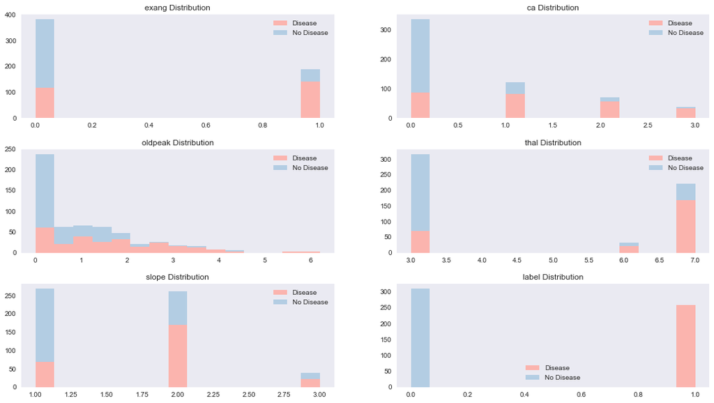

```python
'''
FEATURE VISUALIZATION
'''
current_palette = sns.color_palette('Pastel1')
sns.set_palette(current_palette)

# Plot the distribution of each variable
fig, ax = plt.subplots(3, 2, figsize=(18, 10))
for en, var in enumerate(ex2.columns.values):
    i = (lambda:0, lambda:1)[en > 2]()
    e = (lambda:e+1, lambda:0)[en == 3 or en == 0]()
    ax[e,i].hist([df[df.label>0][var].tolist(), df[df.label<1][var].tolist()],
                 bins=15,
                 stacked=True,
                 rwidth=1.0,
                 label=['Disease', 'No Disease'])
    ax[e,i].set_title(var + ' Distribution')
    ax[e,i].legend()
    ax[e,i].grid()
fig.subplots_adjust(hspace=0.3)
```

## PRE-PROCESSING

```python
'''
PRE-PROCESSING

Convert categorical variables with more than two values into dummy variables.

* Note that variable ca is discrete but not categorical, so we don't convert it.
'''

# Convert cp
dummies = pd.get_dummies(df['cp'],prefix='cp')
df      = df.join(dummies)
del df['cp']
df      = df.rename(columns = {'cp_1.0':'cp_1', 'cp_2.0':'cp_2', 'cp_3.0':'cp_3', 'cp_4.0':'cp_4'})

# Convert restecg
dummies = pd.get_dummies(df['restecg'],prefix='recg')
df      = df.join(dummies)
del df['restecg']
df      = df.rename(columns = {'recg_0.0':'recg_0','recg_1.0':'recg_1', 'recg_2.0':'recg_2'})

# Convert slope
dummies = pd.get_dummies(df['slope'],prefix='slope')
df      = df.join(dummies)
del df['slope']
df      = df.rename(columns = {'slope_1.0':'slope_1','slope_2.0':'slope_2', 'slope_3.0':'slope_3'})

# Convert thal
dummies = pd.get_dummies(df['thal'],prefix='thal')
df      = df.join(dummies)
del df['thal']
df      = df.rename(columns = {'thal_3.0':'thal_3','thal_6.0':'thal_6', 'thal_7.0':'thal_7'})

''' Print Dummy Variables '''
dummy_variable = list(df.loc[:,'cp_1':'thal_7'])
df[dummy_variable].describe()
```

|  | cp_1 | cp_2 | cp_3 | cp_4 | recg_0 | recg_1 | recg_2 | slope_1 | slope_2 | slope_3 | thal_3 | thal_6 | thal_7 |
| --- | --- | --- | --- | --- | --- | --- | --- | --- | --- | --- | --- | --- | --- |
| count | 569.000000 | 569.000000 | 569.000000 | 569.000000 | 569.000000 | 569.000000 | 569.000000 | 569.000000 | 569.000000 | 569.000000 | 569.000000 | 569.000000 | 569.000000 |
| mean | 0.075571 | 0.159930 | 0.284710 | 0.479789 | 0.492091 | 0.010545 | 0.497364 | 0.472759 | 0.458699 | 0.068541 | 0.555360 | 0.056239 | 0.388401 |
| std | 0.264543 | 0.366863 | 0.451673 | 0.500031 | 0.500377 | 0.102235 | 0.500433 | 0.499697 | 0.498730 | 0.252895 | 0.497363 | 0.230585 | 0.487815 |
| min | 0.000000 | 0.000000 | 0.000000 | 0.000000 | 0.000000 | 0.000000 | 0.000000 | 0.000000 | 0.000000 | 0.000000 | 0.000000 | 0.000000 | 0.000000 |
| 25% | 0.000000 | 0.000000 | 0.000000 | 0.000000 | 0.000000 | 0.000000 | 0.000000 | 0.000000 | 0.000000 | 0.000000 | 0.000000 | 0.000000 | 0.000000 |
| 50% | 0.000000 | 0.000000 | 0.000000 | 0.000000 | 0.000000 | 0.000000 | 0.000000 | 0.000000 | 0.000000 | 0.000000 | 1.000000 | 0.000000 | 0.000000 |
| 75% | 0.000000 | 0.000000 | 1.000000 | 1.000000 | 1.000000 | 0.000000 | 1.000000 | 1.000000 | 1.000000 | 0.000000 | 1.000000 | 0.000000 | 1.000000 |
| max | 1.000000 | 1.000000 | 1.000000 | 1.000000 | 1.000000 | 1.000000 | 1.000000 | 1.000000 | 1.000000 | 1.000000 | 1.000000 | 1.000000 | 1.000000 |

```python
# New list of column labels after pre-processing
new_columns = [ 'age', 'sex', 'restbp', 'chol', 'fbs', 'thalach',
                'exang', 'oldpeak', 'ca', 'label',
                'cp_1', 'cp_2', 'cp_3', 'cp_4',
                'recg_0', 'recg_1', 'recg_2',
                'slope_1', 'slope_2', 'slope_3',
                'thal_3', 'thal_6', 'thal_7']

print('\n %i patients in total, out of which %i with desease and %i without disease\n' \
      % (len(df.index),len(df[df.label==1].index),len(df[df.label==0].index)))
```

```
 569 patients in total, out of which 259 with desease and 310 without disease
```

STANDARDIZE AND NORMALIZE

- Normalization scales all numeric variables in the range [0,1]. Columns = 'ca'

[figure not shown]

- Standardization transforms the data to have zero mean and unit variance. Columns = 'age','restbp','chol','thalach','oldpeak'`

[figure not shown]

## SPLITTING THE DATA

We split the data into training and test sets, assigning 75% for training and the remaining 25% for testing. The dataset is also quite balanced, with 310 instances belonging to the absence of category and 259 belonging to the presence of disease category.

# NEURAL NETWORK

# ADAM

Adaptive Moment Estimation

```python
# Initializing the variables
init = tf.global_variables_initializer()

# Merge all the summaries
summaries = tf.summary.merge_all()

# Create Saver
saver = tf.train.Saver()

total_batch = 5
with tf.Session() as sess:
    sess.run(init)

    writer = tf.summary.FileWriter(log_path, sess.graph)

    # Training cycle
    for epoch in range(training_epochs):
        # Loop over all batches
        for batch in range(total_batch):
            batch_x, batch_y = batching(data_train, batch_size=50)

            # Run optimization op (backprop) and cost op (to get loss value)
            curr_loss, cur_accuracy, _, summary = sess.run([cost, accuracy, optimizer, summaries], feed_dict={x: batch_x,
                                                                                                              y: batch_y})
            writer.add_summary(_, batch)

        # Display logs per epoch step
        if epoch % display_step == 0:
            writer.add_summary(summary, epoch * total_batch + batch)
            # Print the loss
            print("Epoch: %04d/%d. Batch: %d/%d. Current loss: %.5f. Train Accuracy: %.3f"
                      %(epoch, training_epochs, batch, total_batch, curr_loss, cur_accuracy))

    # Test the session
    test_accuracy, test_predictions = sess.run([accuracy, y_p], feed_dict={ x: X_test,
                                                                            y: labels_test})

    print("Test Accuracy: %.3f" % test_accuracy)

    saved_value = saver.save(sess, 'model/heart_disease')
```

```
Epoch: 0000/1000. Batch: 4/5. Current loss: 0.69387. Train Accuracy: 0.560
Epoch: 0050/1000. Batch: 4/5. Current loss: 0.26060. Train Accuracy: 0.920
Epoch: 0100/1000. Batch: 4/5. Current loss: 0.25131. Train Accuracy: 0.940
Epoch: 0150/1000. Batch: 4/5. Current loss: 0.03666. Train Accuracy: 1.000
Epoch: 0200/1000. Batch: 4/5. Current loss: 0.08422. Train Accuracy: 0.940
Epoch: 0250/1000. Batch: 4/5. Current loss: 0.00352. Train Accuracy: 1.000
Epoch: 0300/1000. Batch: 4/5. Current loss: 0.00301. Train Accuracy: 1.000
Epoch: 0350/1000. Batch: 4/5. Current loss: 0.00053. Train Accuracy: 1.000
Epoch: 0400/1000. Batch: 4/5. Current loss: 0.00089. Train Accuracy: 1.000
Epoch: 0450/1000. Batch: 4/5. Current loss: 0.00022. Train Accuracy: 1.000
Epoch: 0500/1000. Batch: 4/5. Current loss: 0.00059. Train Accuracy: 1.000
Epoch: 0550/1000. Batch: 4/5. Current loss: 0.00045. Train Accuracy: 1.000
Epoch: 0600/1000. Batch: 4/5. Current loss: 0.00020. Train Accuracy: 1.000
Epoch: 0650/1000. Batch: 4/5. Current loss: 0.00024. Train Accuracy: 1.000
Epoch: 0700/1000. Batch: 4/5. Current loss: 0.00020. Train Accuracy: 1.000
Epoch: 0750/1000. Batch: 4/5. Current loss: 0.00001. Train Accuracy: 1.000
Epoch: 0800/1000. Batch: 4/5. Current loss: 0.00005. Train Accuracy: 1.000
Epoch: 0850/1000. Batch: 4/5. Current loss: 0.00002. Train Accuracy: 1.000
Epoch: 0900/1000. Batch: 4/5. Current loss: 0.00002. Train Accuracy: 1.000
Epoch: 0950/1000. Batch: 4/5. Current loss: 0.00001. Train Accuracy: 1.000
Test Accuracy: 0.944
```

## MODEL ARCHITECTURE

[figure not shown]

```python
from IPython.display import clear_output, Image, display, HTML

def strip_consts(graph_def, max_const_size=32):
    """Strip large constant values from graph_def."""
    strip_def = tf.GraphDef()
    for n0 in graph_def.node:
        n = strip_def.node.add()
        n.MergeFrom(n0)
        if n.op == 'Const':
            tensor = n.attr['value'].tensor
            size = len(tensor.tensor_content)
            if size > max_const_size:
                tensor.tensor_content = "<stripped %d bytes>"%size
    return strip_def

def show_graph(graph_def, max_const_size=32):
    """Visualize TensorFlow graph."""
    if hasattr(graph_def, 'as_graph_def'):
        graph_def = graph_def.as_graph_def()
    strip_def = strip_consts(graph_def, max_const_size=max_const_size)
    code = """
        <script>
          function load() {{
            document.getElementById("{id}").pbtxt = {data};
          }}
        </script>
        <link rel="import" href="https://tensorboard.appspot.com/tf-graph-basic.build.html" onload=load()>
        <div style="height:600px">
          <tf-graph-basic id="{id}"></tf-graph-basic>
        </div>
    """.format(data=repr(str(strip_def)), id='graph'+str(np.random.rand()))

    iframe = """
        <iframe seamless style="width:900px;height:620px;border:0" srcdoc="{}"></iframe>
    """.format(code.replace('"', '&quot;'))
    display(HTML(iframe))

show_graph(tf.get_default_graph().as_graph_def())
```

[interactive chart not shown]

## EVALUATION

```python
'''
Metrics
'''
from sklearn import metrics

print('\nMetrics\n')
print(metrics.classification_report(np.argmax(labels_test,1), test_predictions))

print('\nConfusion Matrix\n')
print(metrics.confusion_matrix(np.argmax(labels_test,1), test_predictions))
```

```
Metrics

             precision    recall  f1-score   support

          0       0.93      0.96      0.94        67
          1       0.96      0.93      0.95        76

avg / total       0.94      0.94      0.94       143


Confusion Matrix

[[64  3]
 [ 5 71]]
```

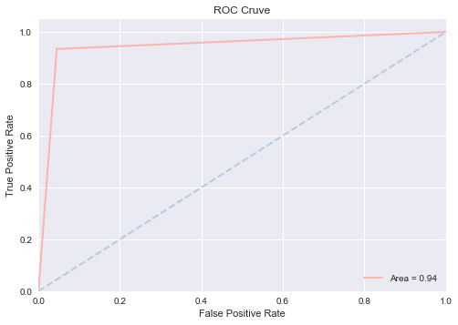

```python
'''
ROC Curve
'''
from sklearn.metrics import roc_curve, auc

fpr, tpr, threshold = roc_curve(np.argmax(labels_test,1), test_predictions)
roc_auc = auc(fpr, tpr)

plt.figure()
lw = 2
plt.plot(fpr, tpr,
         lw=lw, label='Area = %0.2f' % roc_auc)
plt.plot([0, 1], [0, 1], lw=lw, linestyle='--')
plt.xlim([0.0, 1.0])
plt.ylim([0.0, 1.05])
plt.xlabel('False Positive Rate')
plt.ylabel('True Positive Rate')
plt.title('ROC Cruve')
plt.legend(loc="lower right")
plt.show()
```

# Decision Support System

```python
from ipywidgets import *
from IPython.display import display

age = widgets.IntSlider(
    value=20,
    min=1,
    max=99,
    step=1,
    description='Age:',
    disabled=False,
    continuous_update=False,
    orientation='horizontal',
    readout=True,
    readout_format='i',
    slider_color='white'
)

sex = widgets.Dropdown(
    options={'Male': 1, 'Female': 0,},
    value=1,
    description='Sex:',
)

restbp = widgets.IntSlider(
    value=20,
    min=1,
    max=250,
    step=1,
    description='Resting BP:',
    disabled=False,
    continuous_update=False,
    orientation='horizontal',
    readout=True,
    readout_format='i',
    slider_color='white'
)


cholestrol = widgets.IntSlider(
    value=100,
    min=1,
    max=650,
    step=1,
    description='Cholestrol:',
    disabled=False,
    continuous_update=False,
    orientation='horizontal',
    readout=True,
    readout_format='i',
    slider_color='white'
)


fbs = widgets.Dropdown(
    options={'0': 0, '1': 1},
    value=1,
    description='Fasting Blood Sugar:',
)

thalach = widgets.IntSlider(
    value=80,
    min=30,
    max=250,
    step=1,
    description='Max. heart rate:',
    disabled=False,
    continuous_update=False,
    orientation='horizontal',
    readout=True,
    readout_format='i',
    slider_color='white'
)


exang = widgets.Dropdown(
    options={'0': 0, '1': 1},
    value=1,
    description='Exang:',
)


oldpeak = widgets.BoundedFloatText(
    value=5.0,
    min=0,
    max=10.0,
    step=0.1,
    description='Old Peak:',
    disabled=False,
    color='black'
)


ca = widgets.Dropdown(
    options={'0': 0, '1': 1, '2': 2, '3': 3},
    value=1,
    description='CA:',
)


chest_pain = widgets.Dropdown(
    options={'Typical angina': 0, 'Atypical angina': 1, 'Non-Anginal': 2, 'Asumptomatic': 3},
    value=1,
    description='Pain Type:',
)



recg = widgets.Dropdown(
    options={'Normal': 0, 'S-T wave abnormal': 1, 'LV hypertrophy': 2},
    value=1,
    description='Rest ECG:',
)


slope = widgets.Dropdown(
    options={'Upsloping': 0, 'Flat': 1, 'Downsloping': 2},
    value=1,
    description='Slope:',
)


thal = widgets.Dropdown(
    options={'Normal': 0, 'Fixed Defect': 1, 'Reversable Defect': 2},
    value=1,
    description='Thal:',
)

submit = Button(description="submit")

items = [age, sex, restbp, cholestrol, fbs, thalach, exang, oldpeak, ca, chest_pain, recg, slope, thal, submit]

form = VBox(items, layout=Layout(
    display='flex',
    flex_flow='column',
    border='solid 2px',
    align_items='stretch',
    width='40%'
))
display(form)

y_val = []
def on_button_clicked(b):
    cp  = [0,0,0,0]
    rec = [0,0,0]
    slope = [0,0,0]
    thal = [0,0,0]

    for i in items[:-1]:
        #print(i.description)
        if i.description == "Pain Type:":
            cp[i.value] = 1
            y_val.extend(cp)
            continue

        if i.description == 'Rest ECG:':
            rec[i.value] = 1
            y_val.extend(rec)
            continue

        if i.description == "Slope:":
            slope[i.value] = 1
            y_val.extend(slope)
            continue

        if i.description == 'Thal:':
            thal[i.value] =1
            y_val.extend(thal)
            continue

        y_val.append(i.value)

submit.on_click(on_button_clicked)
```

```
Widget Javascript not detected.  It may not be installed or enabled properly.
```

```python
# Predicted value: absence (0) or presence (1)
if classification == 0:
    print('Absence')
else:
    print('Presence')
```

```
Absence
```